# Risk Factor Analysis

## Outcome Variable

**Outcome Variable:** ever_co

## Predictor Variables

**Intervention Variable:** vagbrth

**Adjustment Set:**

- arm
- sex
- W_mage
- meducyrs
- feducyrs
- hhwealth_quart
- W_mhtcm
- W_mwtkg
- W_mbmi
- single
- brthmon
- W_parity
- delta_W_mage
- delta_meducyrs
- delta_feducyrs
- delta_hhwealth_quart
- delta_W_mhtcm
- delta_W_mwtkg
- delta_W_mbmi
- delta_single
- delta_brthmon
- delta_W_parity

## Stratifying Variables

The analysis was stratified on these variable(s):

- agecat
- studyid
- country

## Data Summary

| agecat | studyid | country | vagbrth | ever_co | n_cell | n |
| --- | --- | --- | --- | --- | --- | --- |
| 0-24 months | CMC-V-BCS-2002 | INDIA | 0 | 0 | 21 | 373 |
| 0-24 months | CMC-V-BCS-2002 | INDIA | 0 | 1 | 4 | 373 |
| 0-24 months | CMC-V-BCS-2002 | INDIA | 1 | 0 | 266 | 373 |
| 0-24 months | CMC-V-BCS-2002 | INDIA | 1 | 1 | 82 | 373 |
| 0-24 months | IRC | INDIA | 0 | 0 | 60 | 410 |
| 0-24 months | IRC | INDIA | 0 | 1 | 10 | 410 |
| 0-24 months | IRC | INDIA | 1 | 0 | 274 | 410 |
| 0-24 months | IRC | INDIA | 1 | 1 | 66 | 410 |
| 0-24 months | JiVitA-3 | BANGLADESH | 0 | 0 | 1402 | 26797 |
| 0-24 months | JiVitA-3 | BANGLADESH | 0 | 1 | 111 | 26797 |
| 0-24 months | JiVitA-3 | BANGLADESH | 1 | 0 | 23011 | 26797 |
| 0-24 months | JiVitA-3 | BANGLADESH | 1 | 1 | 2273 | 26797 |
| 0-24 months | JiVitA-4 | BANGLADESH | 0 | 0 | 330 | 4520 |
| 0-24 months | JiVitA-4 | BANGLADESH | 0 | 1 | 41 | 4520 |
| 0-24 months | JiVitA-4 | BANGLADESH | 1 | 0 | 3447 | 4520 |
| 0-24 months | JiVitA-4 | BANGLADESH | 1 | 1 | 702 | 4520 |
| 0-24 months | NIH-Crypto | BANGLADESH | 0 | 0 | 189 | 500 |
| 0-24 months | NIH-Crypto | BANGLADESH | 0 | 1 | 15 | 500 |
| 0-24 months | NIH-Crypto | BANGLADESH | 1 | 0 | 259 | 500 |
| 0-24 months | NIH-Crypto | BANGLADESH | 1 | 1 | 37 | 500 |
| 0-24 months | PROBIT | BELARUS | 0 | 0 | 1949 | 16897 |
| 0-24 months | PROBIT | BELARUS | 0 | 1 | 2 | 16897 |
| 0-24 months | PROBIT | BELARUS | 1 | 0 | 14930 | 16897 |
| 0-24 months | PROBIT | BELARUS | 1 | 1 | 16 | 16897 |
| 0-24 months | PROVIDE | BANGLADESH | 0 | 0 | 144 | 700 |
| 0-24 months | PROVIDE | BANGLADESH | 0 | 1 | 16 | 700 |
| 0-24 months | PROVIDE | BANGLADESH | 1 | 0 | 466 | 700 |
| 0-24 months | PROVIDE | BANGLADESH | 1 | 1 | 74 | 700 |
| 0-24 months | TanzaniaChild2 | TANZANIA, UNITED REPUBLIC OF | 0 | 0 | 203 | 2367 |
| 0-24 months | TanzaniaChild2 | TANZANIA, UNITED REPUBLIC OF | 0 | 1 | 9 | 2367 |

[output cut: 78 more lines]

The following strata were considered:

- agecat: 0-24 months, studyid: CMC-V-BCS-2002, country: INDIA
- agecat: 0-24 months, studyid: IRC, country: INDIA
- agecat: 0-24 months, studyid: JiVitA-3, country: BANGLADESH
- agecat: 0-24 months, studyid: JiVitA-4, country: BANGLADESH
- agecat: 0-24 months, studyid: NIH-Crypto, country: BANGLADESH
- agecat: 0-24 months, studyid: PROBIT, country: BELARUS
- agecat: 0-24 months, studyid: PROVIDE, country: BANGLADESH
- agecat: 0-24 months, studyid: TanzaniaChild2, country: TANZANIA, UNITED REPUBLIC OF
- agecat: 0-24 months, studyid: ZVITAMBO, country: ZIMBABWE
- agecat: 0-6 months, studyid: CMC-V-BCS-2002, country: INDIA
- agecat: 0-6 months, studyid: IRC, country: INDIA
- agecat: 0-6 months, studyid: JiVitA-3, country: BANGLADESH
- agecat: 0-6 months, studyid: JiVitA-4, country: BANGLADESH
- agecat: 0-6 months, studyid: NIH-Crypto, country: BANGLADESH
- agecat: 0-6 months, studyid: PROBIT, country: BELARUS
- agecat: 0-6 months, studyid: PROVIDE, country: BANGLADESH
- agecat: 0-6 months, studyid: TanzaniaChild2, country: TANZANIA, UNITED REPUBLIC OF
- agecat: 0-6 months, studyid: ZVITAMBO, country: ZIMBABWE
- agecat: 6-24 months, studyid: CMC-V-BCS-2002, country: INDIA
- agecat: 6-24 months, studyid: IRC, country: INDIA
- agecat: 6-24 months, studyid: JiVitA-3, country: BANGLADESH
- agecat: 6-24 months, studyid: JiVitA-4, country: BANGLADESH
- agecat: 6-24 months, studyid: NIH-Crypto, country: BANGLADESH
- agecat: 6-24 months, studyid: PROBIT, country: BELARUS
- agecat: 6-24 months, studyid: PROVIDE, country: BANGLADESH
- agecat: 6-24 months, studyid: TanzaniaChild2, country: TANZANIA, UNITED REPUBLIC OF
- agecat: 6-24 months, studyid: ZVITAMBO, country: ZIMBABWE

### Dropped Strata

Some strata were dropped due to rare outcomes:

- agecat: 0-24 months, studyid: CMC-V-BCS-2002, country: INDIA
- agecat: 0-24 months, studyid: PROBIT, country: BELARUS
- agecat: 0-6 months, studyid: CMC-V-BCS-2002, country: INDIA
- agecat: 0-6 months, studyid: NIH-Crypto, country: BANGLADESH
- agecat: 0-6 months, studyid: PROBIT, country: BELARUS
- agecat: 0-6 months, studyid: TanzaniaChild2, country: TANZANIA, UNITED REPUBLIC OF
- agecat: 6-24 months, studyid: CMC-V-BCS-2002, country: INDIA
- agecat: 6-24 months, studyid: PROBIT, country: BELARUS

## Methods Detail

We’re interested in the causal parameters $E[Y_a]$ for all values of $a \in \mathcal{A}$. These parameters represent the mean outcome if, possibly contrary to fact, we intervened to set all units to have $A=a$. Under the randomization and positivity assumptions, these are identified by the statistical parameters $\psi_a=E_W[E_{Y|A,W}(Y|A=a,W)]$. In addition, we’re interested in the mean of $Y$, $E[Y]$ under no intervention (the observed mean). We will estimate these parameters by using SuperLearner to fit the relevant likelihood factors – $E_{Y|A,W}(Y|A=a,W)$ and $p(A=a|W)$, and then updating our likelihood fit using a joint TMLE.

For unadjusted analyses ($W=\{\}$), initial likelihoods were estimated using Lrnr_glm to estimate the simple $E(Y|A)$ and Lrnr_mean to estimate $p(A)$. For adjusted analyses, a small library containing Lrnr_glmnet, Lrnr_xgboost, and Lrnr_mean was used.

Having estimated these parameters, we will then use the delta method to estimate relative risks and attributable risks relative to a prespecified baseline level of $A$.

# Results Detail

## Results Plots

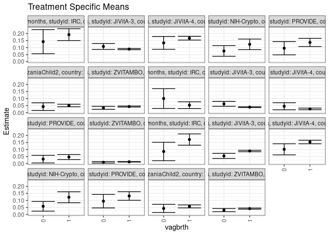

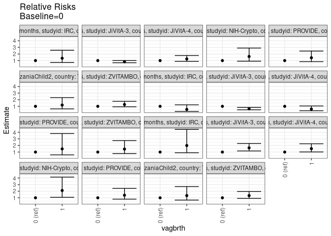

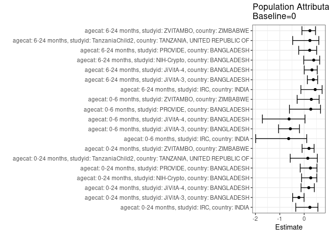

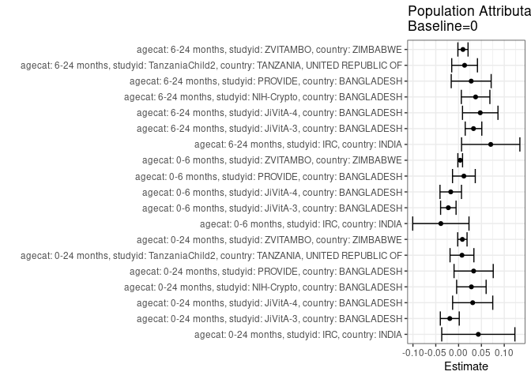

## Results Table

### Parameter: TSM

| agecat | studyid | country | intervention_level | baseline_level | estimate | ci_lower | ci_upper |
| --- | --- | --- | --- | --- | --- | --- | --- |
| 0-24 months | IRC | INDIA | 0 | NA | 0.1421830 | 0.0566032 | 0.2277629 |
| 0-24 months | IRC | INDIA | 1 | NA | 0.1922218 | 0.1500954 | 0.2343482 |
| 0-24 months | JiVitA-3 | BANGLADESH | 0 | NA | 0.1082578 | 0.0870360 | 0.1294796 |
| 0-24 months | JiVitA-3 | BANGLADESH | 1 | NA | 0.0892807 | 0.0852519 | 0.0933095 |
| 0-24 months | JiVitA-4 | BANGLADESH | 0 | NA | 0.1335173 | 0.0880932 | 0.1789414 |
| 0-24 months | JiVitA-4 | BANGLADESH | 1 | NA | 0.1669581 | 0.1537715 | 0.1801447 |
| 0-24 months | NIH-Crypto | BANGLADESH | 0 | NA | 0.0759695 | 0.0382950 | 0.1136439 |
| 0-24 months | NIH-Crypto | BANGLADESH | 1 | NA | 0.1231904 | 0.0856077 | 0.1607731 |
| 0-24 months | PROVIDE | BANGLADESH | 0 | NA | 0.0956172 | 0.0484660 | 0.1427685 |
| 0-24 months | PROVIDE | BANGLADESH | 1 | NA | 0.1366370 | 0.1076062 | 0.1656678 |
| 0-24 months | TanzaniaChild2 | TANZANIA, UNITED REPUBLIC OF | 0 | NA | 0.0424528 | 0.0153069 | 0.0695988 |
| 0-24 months | TanzaniaChild2 | TANZANIA, UNITED REPUBLIC OF | 1 | NA | 0.0505800 | 0.0413259 | 0.0598342 |
| 0-24 months | ZVITAMBO | ZIMBABWE | 0 | NA | 0.0338741 | 0.0233021 | 0.0444461 |
| 0-24 months | ZVITAMBO | ZIMBABWE | 1 | NA | 0.0431131 | 0.0395662 | 0.0466600 |
| 0-6 months | IRC | INDIA | 0 | NA | 0.1000000 | 0.0296358 | 0.1703642 |
| 0-6 months | IRC | INDIA | 1 | NA | 0.0530973 | 0.0291989 | 0.0769957 |
| 0-6 months | JiVitA-3 | BANGLADESH | 0 | NA | 0.0621754 | 0.0447276 | 0.0796232 |
| 0-6 months | JiVitA-3 | BANGLADESH | 1 | NA | 0.0389425 | 0.0364255 | 0.0414595 |
| 0-6 months | JiVitA-4 | BANGLADESH | 0 | NA | 0.0449069 | 0.0196276 | 0.0701862 |
| 0-6 months | JiVitA-4 | BANGLADESH | 1 | NA | 0.0262365 | 0.0203003 | 0.0321726 |
| 0-6 months | PROVIDE | BANGLADESH | 0 | NA | 0.0312500 | 0.0042708 | 0.0582292 |
| 0-6 months | PROVIDE | BANGLADESH | 1 | NA | 0.0462963 | 0.0285609 | 0.0640317 |
| 0-6 months | ZVITAMBO | ZIMBABWE | 0 | NA | 0.0085612 | 0.0032765 | 0.0138458 |
| 0-6 months | ZVITAMBO | ZIMBABWE | 1 | NA | 0.0124157 | 0.0104791 | 0.0143523 |
| 6-24 months | IRC | INDIA | 0 | NA | 0.0857143 | 0.0200549 | 0.1513737 |
| 6-24 months | IRC | INDIA | 1 | NA | 0.1705882 | 0.1305570 | 0.2106194 |
| 6-24 months | JiVitA-3 | BANGLADESH | 0 | NA | 0.0543374 | 0.0362064 | 0.0724684 |
| 6-24 months | JiVitA-3 | BANGLADESH | 1 | NA | 0.0891613 | 0.0842387 | 0.0940840 |
| 6-24 months | JiVitA-4 | BANGLADESH | 0 | NA | 0.1011403 | 0.0615896 | 0.1406910 |
| 6-24 months | JiVitA-4 | BANGLADESH | 1 | NA | 0.1531232 | 0.1406300 | 0.1656165 |
| 6-24 months | NIH-Crypto | BANGLADESH | 0 | NA | 0.0580672 | 0.0236812 | 0.0924532 |
| 6-24 months | NIH-Crypto | BANGLADESH | 1 | NA | 0.1225655 | 0.0835734 | 0.1615576 |
| 6-24 months | PROVIDE | BANGLADESH | 0 | NA | 0.0945464 | 0.0466707 | 0.1424221 |
| 6-24 months | PROVIDE | BANGLADESH | 1 | NA | 0.1314442 | 0.1009022 | 0.1619863 |
| 6-24 months | TanzaniaChild2 | TANZANIA, UNITED REPUBLIC OF | 0 | NA | 0.0430108 | 0.0138471 | 0.0721744 |
| 6-24 months | TanzaniaChild2 | TANZANIA, UNITED REPUBLIC OF | 1 | NA | 0.0574903 | 0.0467609 | 0.0682198 |
| 6-24 months | ZVITAMBO | ZIMBABWE | 0 | NA | 0.0311876 | 0.0196776 | 0.0426975 |
| 6-24 months | ZVITAMBO | ZIMBABWE | 1 | NA | 0.0416451 | 0.0376891 | 0.0456011 |

### Parameter: E(Y)

| agecat | studyid | country | intervention_level | baseline_level | estimate | ci_lower | ci_upper |
| --- | --- | --- | --- | --- | --- | --- | --- |
| 0-24 months | IRC | INDIA | NA | NA | 0.1853659 | 0.1477057 | 0.2230261 |
| 0-24 months | JiVitA-3 | BANGLADESH | NA | NA | 0.0889652 | 0.0850582 | 0.0928722 |
| 0-24 months | JiVitA-4 | BANGLADESH | NA | NA | 0.1643805 | 0.1517702 | 0.1769909 |
| 0-24 months | NIH-Crypto | BANGLADESH | NA | NA | 0.1040000 | 0.0772164 | 0.1307836 |
| 0-24 months | PROVIDE | BANGLADESH | NA | NA | 0.1285714 | 0.1037574 | 0.1533855 |
| 0-24 months | TanzaniaChild2 | TANZANIA, UNITED REPUBLIC OF | NA | NA | 0.0498521 | 0.0410826 | 0.0586217 |
| 0-24 months | ZVITAMBO | ZIMBABWE | NA | NA | 0.0421639 | 0.0388141 | 0.0455137 |
| 0-6 months | IRC | INDIA | NA | NA | 0.0611247 | 0.0378797 | 0.0843697 |
| 0-6 months | JiVitA-3 | BANGLADESH | NA | NA | 0.0396858 | 0.0371902 | 0.0421814 |
| 0-6 months | JiVitA-4 | BANGLADESH | NA | NA | 0.0277157 | 0.0217808 | 0.0336506 |
| 0-6 months | PROVIDE | BANGLADESH | NA | NA | 0.0428571 | 0.0278427 | 0.0578716 |
| 0-6 months | ZVITAMBO | ZIMBABWE | NA | NA | 0.0120886 | 0.0102607 | 0.0139164 |
| 6-24 months | IRC | INDIA | NA | NA | 0.1560976 | 0.1209228 | 0.1912723 |
| 6-24 months | JiVitA-3 | BANGLADESH | NA | NA | 0.0870071 | 0.0823429 | 0.0916713 |
| 6-24 months | JiVitA-4 | BANGLADESH | NA | NA | 0.1485588 | 0.1367632 | 0.1603543 |
| 6-24 months | NIH-Crypto | BANGLADESH | NA | NA | 0.0953390 | 0.0688164 | 0.1218616 |
| 6-24 months | PROVIDE | BANGLADESH | NA | NA | 0.1221498 | 0.0962275 | 0.1480722 |
| 6-24 months | TanzaniaChild2 | TANZANIA, UNITED REPUBLIC OF | NA | NA | 0.0561404 | 0.0460367 | 0.0662440 |
| 6-24 months | ZVITAMBO | ZIMBABWE | NA | NA | 0.0407611 | 0.0370180 | 0.0445043 |

### Parameter: RR

| agecat | studyid | country | intervention_level | baseline_level | estimate | ci_lower | ci_upper |
| --- | --- | --- | --- | --- | --- | --- | --- |
| 0-24 months | IRC | INDIA | 0 | 0 | 1.0000000 | 1.0000000 | 1.0000000 |
| 0-24 months | IRC | INDIA | 1 | 0 | 1.3519321 | 0.7121468 | 2.5664938 |
| 0-24 months | JiVitA-3 | BANGLADESH | 0 | 0 | 1.0000000 | 1.0000000 | 1.0000000 |
| 0-24 months | JiVitA-3 | BANGLADESH | 1 | 0 | 0.8247040 | 0.6753638 | 1.0070672 |
| 0-24 months | JiVitA-4 | BANGLADESH | 0 | 0 | 1.0000000 | 1.0000000 | 1.0000000 |
| 0-24 months | JiVitA-4 | BANGLADESH | 1 | 0 | 1.2504603 | 0.8851647 | 1.7665085 |
| 0-24 months | NIH-Crypto | BANGLADESH | 0 | 0 | 1.0000000 | 1.0000000 | 1.0000000 |
| 0-24 months | NIH-Crypto | BANGLADESH | 1 | 0 | 1.6215775 | 0.9066147 | 2.9003653 |
| 0-24 months | PROVIDE | BANGLADESH | 0 | 0 | 1.0000000 | 1.0000000 | 1.0000000 |
| 0-24 months | PROVIDE | BANGLADESH | 1 | 0 | 1.4289999 | 0.8347022 | 2.4464303 |
| 0-24 months | TanzaniaChild2 | TANZANIA, UNITED REPUBLIC OF | 0 | 0 | 1.0000000 | 1.0000000 | 1.0000000 |
| 0-24 months | TanzaniaChild2 | TANZANIA, UNITED REPUBLIC OF | 1 | 0 | 1.1914411 | 0.6126664 | 2.3169736 |
| 0-24 months | ZVITAMBO | ZIMBABWE | 0 | 0 | 1.0000000 | 1.0000000 | 1.0000000 |
| 0-24 months | ZVITAMBO | ZIMBABWE | 1 | 0 | 1.2727437 | 0.9216783 | 1.7575290 |
| 0-6 months | IRC | INDIA | 0 | 0 | 1.0000000 | 1.0000000 | 1.0000000 |
| 0-6 months | IRC | INDIA | 1 | 0 | 0.5309735 | 0.2303117 | 1.2241361 |
| 0-6 months | JiVitA-3 | BANGLADESH | 0 | 0 | 1.0000000 | 1.0000000 | 1.0000000 |
| 0-6 months | JiVitA-3 | BANGLADESH | 1 | 0 | 0.6263328 | 0.4704082 | 0.8339413 |
| 0-6 months | JiVitA-4 | BANGLADESH | 0 | 0 | 1.0000000 | 1.0000000 | 1.0000000 |
| 0-6 months | JiVitA-4 | BANGLADESH | 1 | 0 | 0.5842413 | 0.3234110 | 1.0554307 |
| 0-6 months | PROVIDE | BANGLADESH | 0 | 0 | 1.0000000 | 1.0000000 | 1.0000000 |
| 0-6 months | PROVIDE | BANGLADESH | 1 | 0 | 1.4814815 | 0.5761031 | 3.8097132 |
| 0-6 months | ZVITAMBO | ZIMBABWE | 0 | 0 | 1.0000000 | 1.0000000 | 1.0000000 |
| 0-6 months | ZVITAMBO | ZIMBABWE | 1 | 0 | 1.4502302 | 0.7672388 | 2.7412165 |
| 6-24 months | IRC | INDIA | 0 | 0 | 1.0000000 | 1.0000000 | 1.0000000 |
| 6-24 months | IRC | INDIA | 1 | 0 | 1.9901961 | 0.8932121 | 4.4344230 |
| 6-24 months | JiVitA-3 | BANGLADESH | 0 | 0 | 1.0000000 | 1.0000000 | 1.0000000 |
| 6-24 months | JiVitA-3 | BANGLADESH | 1 | 0 | 1.6408835 | 1.1679137 | 2.3053919 |
| 6-24 months | JiVitA-4 | BANGLADESH | 0 | 0 | 1.0000000 | 1.0000000 | 1.0000000 |
| 6-24 months | JiVitA-4 | BANGLADESH | 1 | 0 | 1.5139681 | 1.0154391 | 2.2572496 |
| 6-24 months | NIH-Crypto | BANGLADESH | 0 | 0 | 1.0000000 | 1.0000000 | 1.0000000 |
| 6-24 months | NIH-Crypto | BANGLADESH | 1 | 0 | 2.1107528 | 1.0765451 | 4.1384955 |
| 6-24 months | PROVIDE | BANGLADESH | 0 | 0 | 1.0000000 | 1.0000000 | 1.0000000 |
| 6-24 months | PROVIDE | BANGLADESH | 1 | 0 | 1.3902617 | 0.7962112 | 2.4275315 |
| 6-24 months | TanzaniaChild2 | TANZANIA, UNITED REPUBLIC OF | 0 | 0 | 1.0000000 | 1.0000000 | 1.0000000 |
| 6-24 months | TanzaniaChild2 | TANZANIA, UNITED REPUBLIC OF | 1 | 0 | 1.3366501 | 0.6615928 | 2.7005031 |
| 6-24 months | ZVITAMBO | ZIMBABWE | 0 | 0 | 1.0000000 | 1.0000000 | 1.0000000 |
| 6-24 months | ZVITAMBO | ZIMBABWE | 1 | 0 | 1.3353093 | 0.9121912 | 1.9546900 |

### Parameter: PAR

| agecat | studyid | country | intervention_level | baseline_level | estimate | ci_lower | ci_upper |
| --- | --- | --- | --- | --- | --- | --- | --- |
| 0-24 months | IRC | INDIA | 0 | NA | 0.0431828 | -0.0369366 | 0.1233022 |
| 0-24 months | JiVitA-3 | BANGLADESH | 0 | NA | -0.0192926 | -0.0400240 | 0.0014388 |
| 0-24 months | JiVitA-4 | BANGLADESH | 0 | NA | 0.0308632 | -0.0130862 | 0.0748126 |
| 0-24 months | NIH-Crypto | BANGLADESH | 0 | NA | 0.0280305 | -0.0042631 | 0.0603241 |
| 0-24 months | PROVIDE | BANGLADESH | 0 | NA | 0.0329542 | -0.0099709 | 0.0758793 |
| 0-24 months | TanzaniaChild2 | TANZANIA, UNITED REPUBLIC OF | 0 | NA | 0.0073993 | -0.0187121 | 0.0335107 |
| 0-24 months | ZVITAMBO | ZIMBABWE | 0 | NA | 0.0082898 | -0.0019477 | 0.0185272 |
| 0-6 months | IRC | INDIA | 0 | NA | -0.0388753 | -0.1004926 | 0.0227420 |
| 0-6 months | JiVitA-3 | BANGLADESH | 0 | NA | -0.0224896 | -0.0394410 | -0.0055382 |
| 0-6 months | JiVitA-4 | BANGLADESH | 0 | NA | -0.0171912 | -0.0407362 | 0.0063538 |
| 0-6 months | PROVIDE | BANGLADESH | 0 | NA | 0.0116071 | -0.0133041 | 0.0365183 |
| 0-6 months | ZVITAMBO | ZIMBABWE | 0 | NA | 0.0035274 | -0.0016223 | 0.0086771 |
| 6-24 months | IRC | INDIA | 0 | NA | 0.0703833 | 0.0065372 | 0.1342293 |
| 6-24 months | JiVitA-3 | BANGLADESH | 0 | NA | 0.0326697 | 0.0145031 | 0.0508363 |
| 6-24 months | JiVitA-4 | BANGLADESH | 0 | NA | 0.0474184 | 0.0085775 | 0.0862594 |
| 6-24 months | NIH-Crypto | BANGLADESH | 0 | NA | 0.0372718 | 0.0060215 | 0.0685221 |
| 6-24 months | PROVIDE | BANGLADESH | 0 | NA | 0.0276035 | -0.0161251 | 0.0713320 |
| 6-24 months | TanzaniaChild2 | TANZANIA, UNITED REPUBLIC OF | 0 | NA | 0.0131296 | -0.0150486 | 0.0413078 |
| 6-24 months | ZVITAMBO | ZIMBABWE | 0 | NA | 0.0095735 | -0.0015754 | 0.0207224 |

### Parameter: PAF

| agecat | studyid | country | intervention_level | baseline_level | estimate | ci_lower | ci_upper |
| --- | --- | --- | --- | --- | --- | --- | --- |
| 0-24 months | IRC | INDIA | 0 | NA | 0.2329599 | -0.3450125 | 0.5625688 |
| 0-24 months | JiVitA-3 | BANGLADESH | 0 | NA | -0.2168560 | -0.4735495 | -0.0048787 |
| 0-24 months | JiVitA-4 | BANGLADESH | 0 | NA | 0.1877548 | -0.1289134 | 0.4155952 |
| 0-24 months | NIH-Crypto | BANGLADESH | 0 | NA | 0.2695243 | -0.1083192 | 0.5185549 |
| 0-24 months | PROVIDE | BANGLADESH | 0 | NA | 0.2563105 | -0.1622722 | 0.5241440 |
| 0-24 months | TanzaniaChild2 | TANZANIA, UNITED REPUBLIC OF | 0 | NA | 0.1484250 | -0.5741345 | 0.5393151 |
| 0-24 months | ZVITAMBO | ZIMBABWE | 0 | NA | 0.1966083 | -0.0862429 | 0.4058067 |
| 0-6 months | IRC | INDIA | 0 | NA | -0.6360000 | -1.9871157 | 0.1039865 |
| 0-6 months | JiVitA-3 | BANGLADESH | 0 | NA | -0.5666914 | -1.0536717 | -0.1951872 |
| 0-6 months | JiVitA-4 | BANGLADESH | 0 | NA | -0.6202691 | -1.7148580 | 0.0329984 |
| 0-6 months | PROVIDE | BANGLADESH | 0 | NA | 0.2708333 | -0.6021007 | 0.6681332 |
| 0-6 months | ZVITAMBO | ZIMBABWE | 0 | NA | 0.2917948 | -0.2882946 | 0.6106833 |
| 6-24 months | IRC | INDIA | 0 | NA | 0.4508929 | -0.1352628 | 0.7344063 |
| 6-24 months | JiVitA-3 | BANGLADESH | 0 | NA | 0.3754832 | 0.1300239 | 0.5516874 |
| 6-24 months | JiVitA-4 | BANGLADESH | 0 | NA | 0.3191897 | 0.0020304 | 0.5355544 |
| 6-24 months | NIH-Crypto | BANGLADESH | 0 | NA | 0.3909396 | -0.0179552 | 0.6355885 |
| 6-24 months | PROVIDE | BANGLADESH | 0 | NA | 0.2259803 | -0.2244636 | 0.5107192 |
| 6-24 months | TanzaniaChild2 | TANZANIA, UNITED REPUBLIC OF | 0 | NA | 0.2338710 | -0.4720286 | 0.6012620 |
| 6-24 months | ZVITAMBO | ZIMBABWE | 0 | NA | 0.2348693 | -0.0929840 | 0.4643791 |